# PML_JYPROJECT

JY

12 de enero de 2019

# Summary:

# Setup

```r
library(caret)
library(ggplot2)
library(dplyr)
```

# Loading Data

```r
training <- read.csv("pml-training.csv")
testing <- read.csv("pml-testing.csv")
```

# Exploratory Data Analysis

The training set contains a vast amount of data with 19622 observations and 160 variables. The test dataset only contains 20 observations over the same number of variables.

[figure not shown]

```r
na_count <-data.frame(N = sapply(training, function(y) sum(length(which(is.na(y))))))

na_count$type <- na_count>0

ggplot(na_count , aes(x=type,fill=type))+geom_bar()+ theme_classic()+ggtitle("Number of Variables")+xlab("Without NA's")
```

The process of feature selection consisted on selecting variables with variance and iterating with Random Forest algorithm considering his high performance. Starting from 1 variable and adding new variables checking the accuracy on cross validation and making visual inspections on variables tested (see Image below). I have not tested training the model with all the variables due to limitations on computer capacity.  
In this example the variable *pitch_belt* showed discriminatory capacity on the problem given the different distributions by classe.

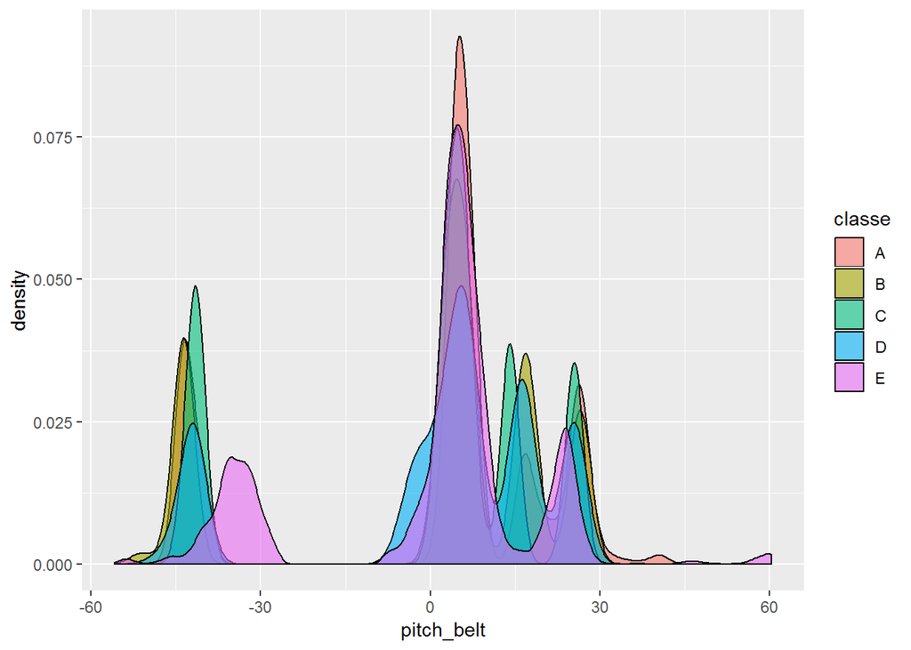

```r
ggplot(training, aes(x=pitch_belt, fill = classe))+geom_density(alpha = 0.6)
```

# Cross Validation Config

In this section I configured the Cross-validation process for training the models. I used 5-Fold cross validation given the amount of data available. In a case with less data it worth using more fold and even bootstrapping.

```r
kfold_config<-trainControl(method="cv",
                           number= 5,
                           summaryFunction=defaultSummary,
                           classProbs = TRUE,
                           savePredictions = T,
                           verboseIter = F)
```

# Model training

I trained several state of the classification algorithms. The pre-process used is *center* and *scale* for standarizing variables and improving performance. The models trained are: Linear Discriminant Analysis, Naive Bayes, Decision Tree, Random Forest and Gradien Boosting Machine.

```r
f <- as.formula("classe ~ roll_belt + pitch_belt + yaw_belt +roll_dumbbell+pitch_dumbbell+yaw_dumbbell+ magnet_forearm_x+magnet_forearm_y+magnet_forearm_z+accel_forearm_x+ accel_forearm_y+ accel_forearm_z+magnet_belt_z")

rf_model <- train(f,
                  data=training,
                  trControl=kfold_config,
                  na.action = na.omit,
                  method="rf",
                  preProcess=c("center","scale"),
                  ntree=500,
                  tuneGrid=expand.grid(.mtry=c(2)))

gbm_model <- train(f,
                  data=training,
                  trControl=kfold_config,
                  na.action = na.omit,
                  method="gbm",
                  preProcess=c("center","scale"),
                  verbose=FALSE)

rpart.grid<- expand.grid(cp=c(0.01))
dt_model <- train(f,
                  data=training,
                  trControl=kfold_config,
                  na.action = na.omit,
                  method="rpart",
                  tuneGrid = rpart.grid,
                  preProcess=c("center","scale"))
lda_model <- train(f,
                  data=training,
                  trControl=kfold_config,
                  na.action = na.omit,
                  method="lda",
                  preProcess=c("center","scale"))

nb_model <- train(f,
                  data=training,
                  trControl=kfold_config,
                  na.action = na.omit,
                  method="naive_bayes",
                  preProcess=c("center","scale"))
```

## Summary of Performance on Cross-validation training

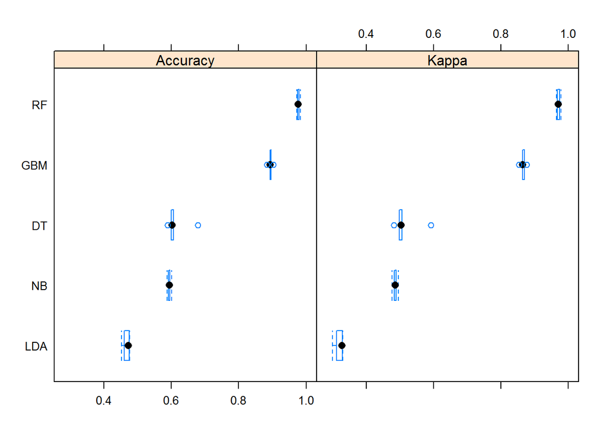

```r
results <- resamples(list(GBM = gbm_model, DT = dt_model,RF = rf_model, NB=nb_model, LDA = lda_model))
bwplot(results)
```

# Prediction on test set

```r
data.frame(Case=testing$X, Prediction = predict(gbm_model, testing))
```

```
##    Case Prediction
## 1     1          B
## 2     2          A
## 3     3          B
## 4     4          A
## 5     5          A
## 6     6          E
## 7     7          D
## 8     8          B
## 9     9          A
## 10   10          A
## 11   11          B
## 12   12          C
## 13   13          B
## 14   14          A
## 15   15          E
## 16   16          E
## 17   17          A
## 18   18          B
## 19   19          B
## 20   20          B
```